# Project ANOVA

Tatiana Kikalova, Valeriia Ladyhina, Anastasiia Rusanova

2021-11-24

| *In this project we analysed data regarding effect of drugs of interest on patients obtained by 20 medical doctors.* |
| --- |

Now the script will automatically download and install all required R libraries. Please wait a bit.

```r
requiredPackages = c('tidyverse','ggplot2','prettydoc','dplyr','RColorBrewer','car')
for(p in requiredPackages){
  if(!require(p,character.only = TRUE)) install.packages(p, repos = "http://cran.us.r-project.org" )
  library(p,character.only = TRUE)
}
```

**Task 1: Data collection**

To merge all files into one data frame you can use next function.

```r
merge_csv_files_in_one_dataframe<-function(file_path, file_type){
  filenames=list.files(path=file_path, pattern = file_type, full.names=TRUE)
 do.call(rbind,lapply(filenames, read.csv))
  }
```

Merging files into one data frame named data_drug_effects.

```r
data_drug_effects<-merge_csv_files_in_one_dataframe('./Data', '.csv')
```

**Task 2: Check for normality of the data. EDA**

First let’s explore data structure and type of variables we have in out dataframe

```r
str(data_drug_effects)
```

```
## 'data.frame':    200 obs. of  7 variables:
##  $ X               : int  1 2 3 4 5 6 7 8 9 10 ...
##  $ gender          : chr  "female" "female" "female" "female" ...
##  $ age             : chr  "26" "26" "31" "28" ...
##  $ drug_type       : chr  "Placebo" "Placebo" "Placebo" "Placebo" ...
##  $ is_relapse      : int  0 1 0 1 1 NA 0 1 1 0 ...
##  $ id              : int  101 102 103 104 105 106 107 108 109 110 ...
##  $ days_in_hospital: num  25.2 23.3 29.9 27.8 23.3 ...
```

We see that our data has variables such as gender, drug_type, is_relapse that potentially would be better to turn into factors. As current data set is quite small we will perform two kind of analysis: a)check of unique unique values in the whole data set, b)visualisation of the data to reveal outliers.

**a)**

```
## $X
##   [1]   1   2   3   4   5   6   7   8   9  10  91  92  93  94  95  96  97  98
##  [19]  99 100 101 102 103 104 105 106 107 108 109 110 111 112 113 114 115 116
##  [37] 117 118 119 120 121 122 123 124 125 126 127 128 129 130 131 132 133 134
##  [55] 135 136 137 138 139 140 141 142 143 144 145 146 147 148 149 150 151 152
##  [73] 153 154 155 156 157 158 159 160 161 162 163 164 165 166 167 168 169 170
##  [91] 171 172 173 174 175 176 177 178 179 180 181 182 183 184 185 186 187 188
## [109] 189 190  11  12  13  14  15  16  17  18  19  20 191 192 193 194 195 196
## [127] 197 198 199 200  21  22  23  24  25  26  27  28  29  30  31  32  33  34
## [145]  35  36  37  38  39  40  41  42  43  44  45  46  47  48  49  50  51  52
## [163]  53  54  55  56  57  58  59  60  61  62  63  64  65  66  67  68  69  70
## [181]  71  72  73  74  75  76  77  78  79  80  81  82  83  84  85  86  87  88
## [199]  89  90
##
## $gender
```

[output cut: 54 more lines]

Variables X and id repeating information, so we will remove one of them. Variables age and gender have mistaken values that we will later manually fix.

```r
data_drug_effects <- select(data_drug_effects, -X)
```

Check for NAs.

```r
 which(is.na(data_drug_effects), arr.ind=TRUE)
```

```
##       row col
##  [1,]   6   4
##  [2,]  25   4
##  [3,]  71   4
##  [4,]  90   4
##  [5,]  92   4
##  [6,] 143   4
##  [7,] 169   4
##  [8,] 179   4
##  [9,] 185   4
## [10,] 186   4
```

There are 10 NAs in our data, but all of them located in is_relapsed column.

**b)**

Now we will perform visualization of the data using second way for outliers search.

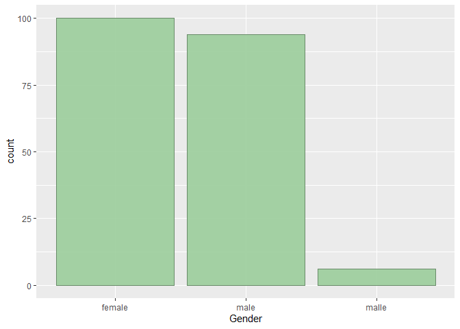

```r
ggplot(data_drug_effects, aes(gender))+
  geom_bar(fill="darkseagreen3", color="darkseagreen4", alpha=0.9) +
  xlab("Gender") +
  theme_set(theme_bw())
```

Gender has expected female and male groups and mistaken **malle** group that will be fixed manually together with changing the type of variable gender to factor.

```r
data_drug_effects$gender[data_drug_effects$gender=='malle']<-'male'
data_drug_effects$gender<- factor(data_drug_effects$gender, labels = c('Female','Male'))
```

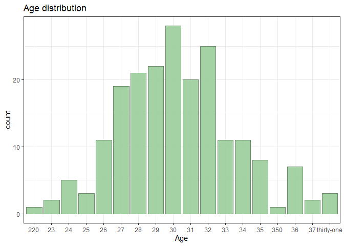

```r
ggplot(data_drug_effects,aes(age))+
  geom_bar(fill="darkseagreen3", color="darkseagreen4", alpha=0.9) +
  xlab("Age") +
  labs(title = 'Age distribution') +
  theme_set(theme_bw())
```

Plot revealed three strange values: 220, 350 and ’thirty-one, so we will manually fix them. Also the type of variable age is charachter we will change it to numeric

```r
data_drug_effects$age[data_drug_effects$age==220]<-22
data_drug_effects$age[data_drug_effects$age==350]<-35
data_drug_effects$age[data_drug_effects$age=='thirty-one']<-31
data_drug_effects$age<-as.numeric(data_drug_effects$age)
```

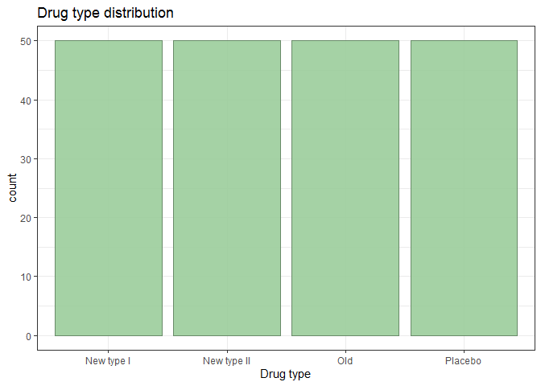

```r
ggplot(data_drug_effects,aes(drug_type))+
    geom_bar(fill="darkseagreen3", color="darkseagreen4", alpha=0.9) +
    xlab("Drug type") +
  scale_x_discrete(labels=c("New type I", "New type II", "Old", "Placebo")) +
    labs(title = 'Drug type distribution') +
    theme_bw()
```

Drug_type variable is of character type, we will change it to factor.

```r
data_drug_effects$drug_type<-factor(data_drug_effects$drug_type, labels = c('NT1', 'NT2', 'Old Type', 'Placebo'))
```

It would have more sense to use is_relapce variable as factor so we will convert it to a factor variable.

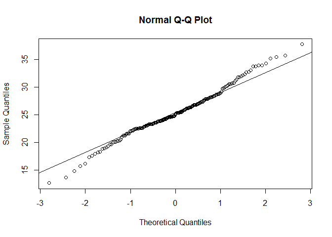

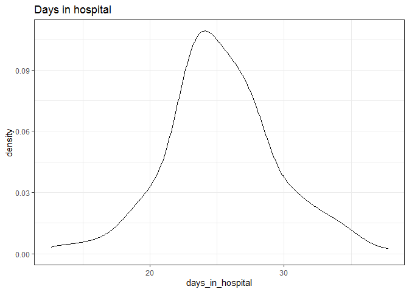

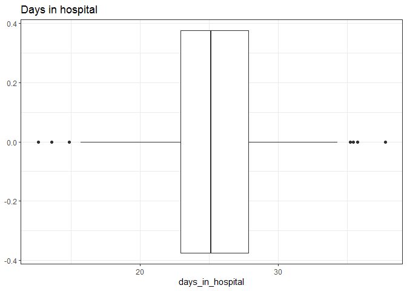

```r
qqnorm(data_drug_effects$days_in_hospital)
qqline(data_drug_effects$days_in_hospital)
ggplot(data_drug_effects,aes(days_in_hospital))+
    geom_density()+
    theme_bw()+
    labs( title = 'Days in hospital')
ggplot(data_drug_effects,aes(days_in_hospital))+
    geom_boxplot()+
    theme_bw()+
    labs( title = 'Days in hospital')
```

Variable days_in_hospital does not have any significant outliers and has a normal distribution.

**Task 3: Count mean and standard deviation of days that were needed for treatment without dependency on gender.**

```r
Mean_days_in_hospital<-mean(data_drug_effects$days_in_hospital)
SD_days_in_hospital<-sd(data_drug_effects$days_in_hospital)
```

Answer

Mean value of variable days_in_hospital is **25.3226681** while it’s standard deviation is **4.1971996**.

**Task 4: Visualization of number of days needed for treatment in hospital among women and men.**

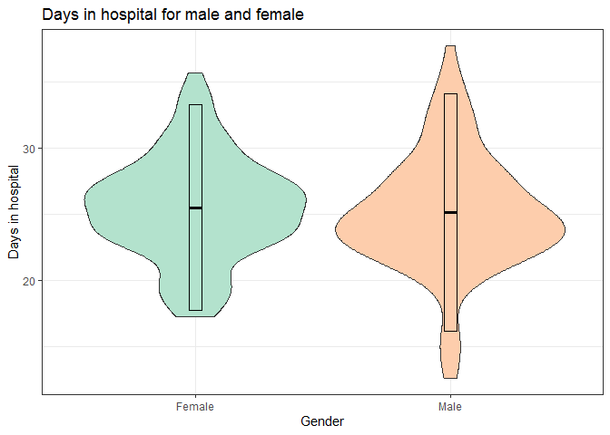

```r
ggplot(data_drug_effects,aes(x = gender,y = days_in_hospital)) +
    geom_violin(aes(fill = gender), show.legend = FALSE) +
    stat_summary(fun.data="mean_sdl", geom="crossbar", width=0.05 )+
    scale_fill_brewer(palette="Pastel2") +
    xlab("Gender")+
    ylab("Days in hospital")+
    theme_bw()+
    labs( title = 'Days in hospital for male and female')
```

**Task 5: Is there any difference in time that was needed for treatment between women who had placebo and New Type 2 drug.**

**1. Firstly, we are going to visualize the percentage of women who spent different time in hospital. We decided to split them in 2 groups dividing by the criteria if they spent more time in hospital than average, or less.**

Here is the percent stacked barplot describing our results:

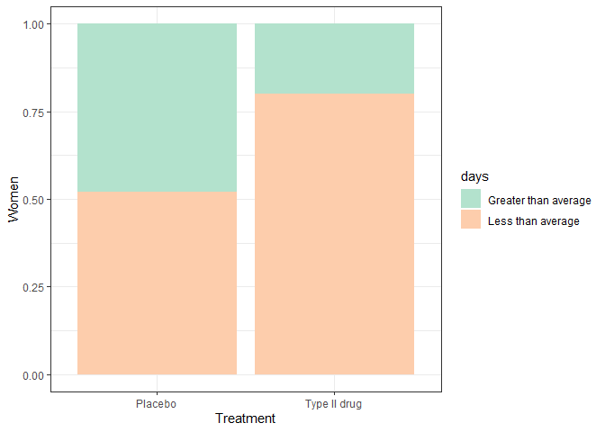

```r
women_days_mean <- data_drug_effects %>% filter(gender == "Female") %>% summarize(Mean = mean(days_in_hospital, na.rm=TRUE)) %>% .$Mean

women_days_Placebo_greater <- data_drug_effects %>% filter(gender == "Female", drug_type == "Placebo") %>% filter(days_in_hospital > women_days_mean) %>% count() %>% .$n
women_days_Placebo_less <- data_drug_effects %>% filter(gender == "Female", drug_type == "Placebo") %>% filter(days_in_hospital < women_days_mean) %>% count() %>% .$n

women_days_type2_greater <- data_drug_effects %>% filter(gender == "Female", drug_type == "NT2") %>% filter(days_in_hospital > women_days_mean) %>% count() %>% .$n
women_days_type2_less <- data_drug_effects %>% filter(gender == "Female", drug_type == "NT2") %>% filter(days_in_hospital < women_days_mean) %>% count() %>% .$n

mosaic_women <- data.frame(c(women_days_Placebo_greater, women_days_Placebo_less), c(women_days_type2_greater, women_days_type2_less))
colnames(mosaic_women) <- c("Placebo", "Type II drug")
rownames(mosaic_women) <- c("Greater than average", "Less than average")

# create a dataset
treatment <- c(rep("Placebo" , 2) , rep("Type II drug" , 2))
days <- rep(c("Greater than average" , "Less than average"), 2)
women <- c(women_days_Placebo_greater, women_days_Placebo_less, women_days_type2_greater, women_days_type2_less)
data <- data.frame(treatment,days,women)

# Stacked + percent
ggplot(data, aes(x = treatment, y = women, fill=days)) +
  geom_bar(position="fill", stat="identity") +
  xlab("Treatment") +
  ylab("Women") +
  scale_fill_brewer(palette="Pastel2") +
  theme_set(theme_bw())
```

**2. Secondly, we can visualize days spent in hospital by women treated by Placebo and Type II drug with Violin plot:**

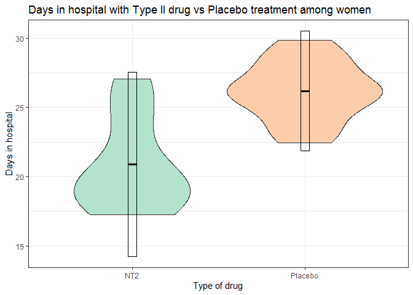

```r
data_drug_effects_women_placebo_vs_nt2<- data_drug_effects%>%
                                         filter(drug_type == c('Placebo','NT2'), gender == 'Female')
ggplot(data_drug_effects_women_placebo_vs_nt2,aes(x = drug_type,y = days_in_hospital)) +
    geom_violin(aes(fill = drug_type), show.legend = FALSE) +
    stat_summary(fun.data="mean_sdl", geom="crossbar", width=0.05)+
    scale_fill_brewer(palette="Pastel2") +
    xlab("Type of drug")+
    ylab("Days in hospital")+
    theme_bw()+
    labs( title = 'Days in hospital with Type II drug vs Placebo treatment among women')
```

Results

As we can see, the percentage of women that were treated with Type II drug and spent less days in hospital than average, is observably greater. And that means, that the number of days spent in the hospital by women, treated with Type II drug, is less than by women who received a Placebo.

**3. ANOVA analysis**

```r
women_days <- data_drug_effects %>% filter(gender == "Female", drug_type == c('Placebo','NT2')) %>% select(days_in_hospital, drug_type)
```

Here are the mean values for Days spent in hospital for 2 women groups in the analysis:

```r
tapply(women_days$days_in_hospital, women_days$drug_type, mean)
```

```
##      NT1      NT2 Old Type  Placebo
##       NA 20.88786       NA 26.19528
```

Now let’s check if there is a statistical difference between these values:

```r
sstest <- t.test(women_days$days_in_hospital[women_days$drug_type == "Placebo"], women_days$days_in_hospital[women_days$drug_type == "NT2"])
sstest
```

```
##
##  Welch Two Sample t-test
##
## data:  women_days$days_in_hospital[women_days$drug_type == "Placebo"] and women_days$days_in_hospital[women_days$drug_type == "NT2"]
## t = 4.8295, df = 20.591, p-value = 9.441e-05
## alternative hypothesis: true difference in means is not equal to 0
## 95 percent confidence interval:
##  3.019241 7.595614
## sample estimates:
## mean of x mean of y
##  26.19528  20.88786
```

Results

As a result of the Student’s t-Test analysis, we were able to reject the Null hypothesis that there is no difference for the amount of days in hospital spent by women treated with Placebo vs women treated with Type II drug *(statistic value = 4.8295, women sample size _Placebo = 13, women sample size_Type II drug = 13, p-value = 9.441e-05).

**Task 6: Is there any difference in time that was needed for treatment between patient with different drug treatment.**

```r
install.packages('multcomp', repos = "http://cran.us.r-project.org" )
library(multcomp)
```

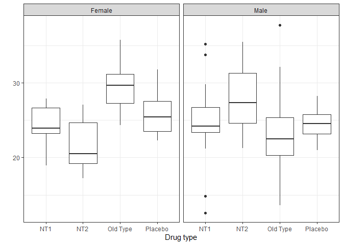

```r
ggplot(data_drug_effects, aes(x = drug_type, y = days_in_hospital)) + geom_boxplot() +
  labs(x = "Drug type", y = "")  +
  facet_grid(cols=vars(gender))
```

Earlier we tested variable days_in_hospital and it seemed to be normal, but let’ also test it’s normality of distribution based on Shapiro-Wilk test.

```r
test <- shapiro.test(data_drug_effects$days_in_hospital)
```

Resulting p-value is **0.1009467** which means that we have normal distribution.

```r
model <- lm(days_in_hospital ~ drug_type*gender, data = data_drug_effects)
summary(model)
```

```
##
## Call:
## lm(formula = days_in_hospital ~ drug_type * gender, data = data_drug_effects)
##
## Residuals:
##      Min       1Q   Median       3Q      Max
## -12.1535  -2.0786  -0.4873   2.3024  14.4718
##
## Coefficients:
##                              Estimate Std. Error t value Pr(>|t|)
## (Intercept)                   24.6342     0.7174  34.339  < 2e-16 ***
## drug_typeNT2                  -2.6619     1.0145  -2.624   0.0094 **
## drug_typeOld Type              4.9572     1.0145   4.886 2.16e-06 ***
## drug_typePlacebo               1.2104     1.0145   1.193   0.2343
## genderMale                     0.1339     1.0145   0.132   0.8951
## drug_typeNT2:genderMale        5.7146     1.4348   3.983 9.65e-05 ***
## drug_typeOld Type:genderMale  -6.4725     1.4348  -4.511 1.12e-05 ***
## drug_typePlacebo:genderMale   -1.2814     1.4348  -0.893   0.3729
## ---
## Signif. codes:  0 '***' 0.001 '**' 0.01 '*' 0.05 '.' 0.1 ' ' 1
##
## Residual standard error: 3.587 on 192 degrees of freedom
## Multiple R-squared:  0.2954, Adjusted R-squared:  0.2697
## F-statistic:  11.5 on 7 and 192 DF,  p-value: 3.642e-12
```

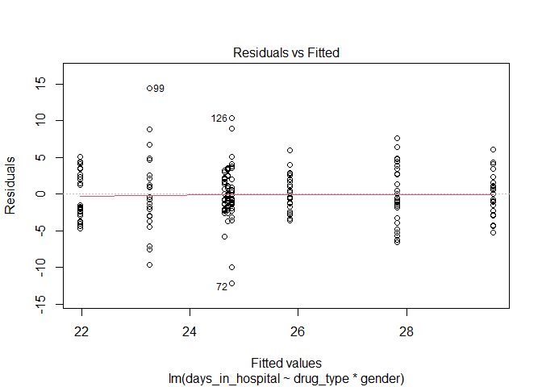

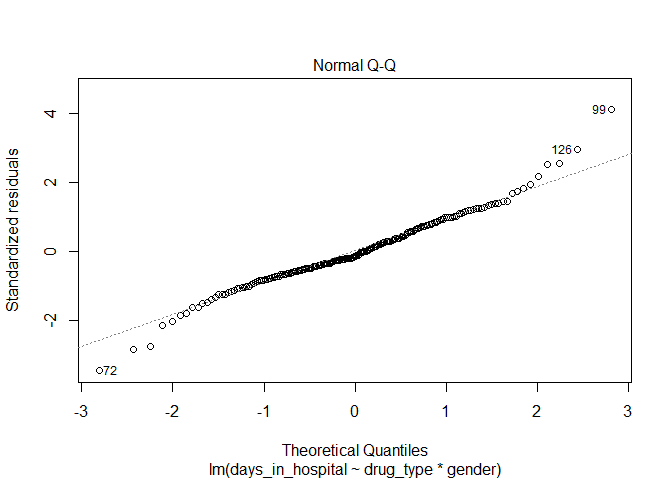

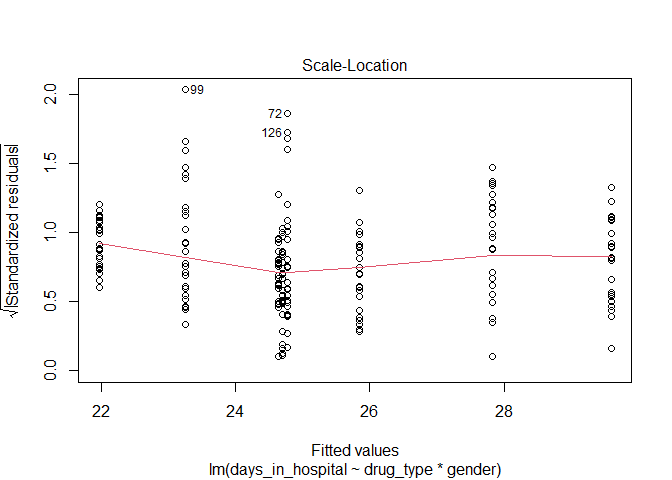

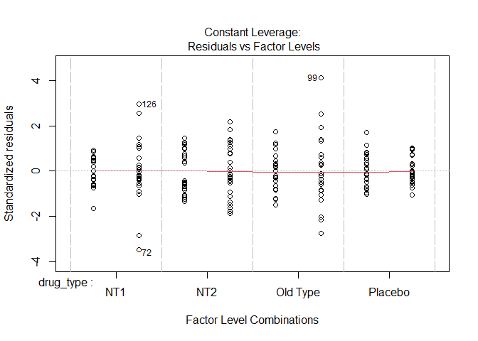

```r
plot(model)
```

```r
anova_model <- Anova(model)
summary(anova_model)
```

```
##      Sum Sq               Df            F value            Pr(>F)
##  Min.   :   7.064   Min.   :  1.00   Min.   : 0.5491   Min.   :0.00000
##  1st Qu.:  68.490   1st Qu.:  2.50   1st Qu.: 1.4270   1st Qu.:0.03909
##  Median : 514.184   Median :  3.00   Median : 2.3049   Median :0.07818
##  Mean   : 876.420   Mean   : 49.75   Mean   : 9.0641   Mean   :0.17926
##  3rd Qu.:1322.114   3rd Qu.: 50.25   3rd Qu.:13.3217   3rd Qu.:0.26889
##  Max.   :2470.247   Max.   :192.00   Max.   :24.3384   Max.   :0.45961
##                                      NA's   :1         NA's   :1
```

```r
aov_model <- aov(days_in_hospital ~ drug_type*gender, data = data_drug_effects)
summary(aov_model)
```

```
##                   Df Sum Sq Mean Sq F value   Pr(>F)
## drug_type          3   89.0   29.66   2.305   0.0782 .
## gender             1    7.1    7.06   0.549   0.4596
## drug_type:gender   3  939.4  313.13  24.338 2.16e-13 ***
## Residuals        192 2470.2   12.87
## ---
## Signif. codes:  0 '***' 0.001 '**' 0.01 '*' 0.05 '.' 0.1 ' ' 1
```

```r
tukeytest_gender <- glht(aov_model, linfct = mcp(gender = "Tukey"))
summary(tukeytest_gender)
```

```
##
##   Simultaneous Tests for General Linear Hypotheses
##
## Multiple Comparisons of Means: Tukey Contrasts
##
##
## Fit: aov(formula = days_in_hospital ~ drug_type * gender, data = data_drug_effects)
##
## Linear Hypotheses:
##                    Estimate Std. Error t value Pr(>|t|)
## Male - Female == 0   0.1339     1.0145   0.132    0.895
## (Adjusted p values reported -- single-step method)
```

```r
tukeytest_drug <- glht(aov_model, linfct = mcp(drug_type = "Tukey"))
summary(tukeytest_drug)
```

```
##
##   Simultaneous Tests for General Linear Hypotheses
##
## Multiple Comparisons of Means: Tukey Contrasts
##
##
## Fit: aov(formula = days_in_hospital ~ drug_type * gender, data = data_drug_effects)
##
## Linear Hypotheses:
##                         Estimate Std. Error t value Pr(>|t|)
## NT2 - NT1 == 0            -2.662      1.015  -2.624  0.04588 *
## Old Type - NT1 == 0        4.957      1.015   4.886  < 0.001 ***
## Placebo - NT1 == 0         1.210      1.015   1.193  0.63195
## Old Type - NT2 == 0        7.619      1.015   7.510  < 0.001 ***
## Placebo - NT2 == 0         3.872      1.015   3.817  0.00103 **
## Placebo - Old Type == 0   -3.747      1.015  -3.693  0.00162 **
## ---
## Signif. codes:  0 '***' 0.001 '**' 0.01 '*' 0.05 '.' 0.1 ' ' 1
## (Adjusted p values reported -- single-step method)
```

Results

The combination of the type of drug taken and the gender of the patient significantly affects the time of hospitalization,type 2 drug slows down treatment in men but speeds up treatment in women. The old type of drug slows down treatment in women, but does not have a significant effect in men.